[GitHub](https://github.com/Janssena/DeepCompartmentModels.jl)[](https://github.com/Janssena/DeepCompartmentModels.jl/blob/main/tutorials/02-mixed-effects.qmd)

# Mixed effects with the variational ELBO

*Inter-individual variability on top of the covariate model, fitted on warfarin*

The model in the first tutorial maps covariates to parameters deterministically, so two patients with the same weight get the same curve. Real patients differ for reasons the covariates do not capture. The standard pharmacometric answer is a *mixed-effects model*: every individual `i` gets random effects `ηᵢ`, and their parameters are

\[z_i = \zeta(x_i) \cdot \exp(\eta_i), \qquad \eta_i \sim \mathcal{N}(0, \Omega),\]

where `ζ(x)` is the output of the neural network (the *typical* parameters) and `Ω` the covariance of the random effects. Together with a residual error model this defines a likelihood. Here the random effects are inferred with variational inference: each individual gets a Gaussian posterior `q(ηᵢ) = N(μᵢ, Lᵢ Lᵢᵀ)`, and the network weights, the posteriors and the error parameters are trained jointly by maximising the evidence lower bound (ELBO).

```julia
using DeepCompartmentModels
using DataFrames, CSV
using CairoMakie
using Random
using Statistics: mean
```

## Data

We use the warfarin concentrations, loaded as in the data tutorial.

```julia
warfarin = DataFrame(CSV.File(joinpath(pkgdir(DeepCompartmentModels), "data", "warfarin.csv")))
warfarin = warfarin[warfarin.DVID .== 1, :]

function make_individual(g)
    covariates = Float32[g.WEIGHT[1], g.AGE[1], g.SEX[1]]
    doses = Matrix{Float32}(g[g.MDV .== 1, [:TIME, :DOSE, :RATE, :DURATION]])
    obs = g[g.MDV .== 0, :]
    return Individual(g.ID[1], covariates, obs.TIME, obs.DV, generate_dosing_callback(doses))
end

population = Population([make_individual(g) for g in groupby(warfarin, :ID)])
length(population)
```

```
32
```

## Model

A one-compartment model with first-order absorption, parameters `[kₐ, CL, V]`, and a network from weight, age and sex. The final layer scales the outputs to plausible magnitudes for warfarin (clearance around 0.1 L/h, volume around 10 L).

```julia
ann = Lux.Chain(
    Normalize(Float32[100, 100, 1]),
    Lux.Dense(3, 16, tanh),
    Lux.Dense(16, 3, Lux.softplus),
    Lux.WrappedFunction(x -> x .* Float32[1, 0.2, 10]),
)

problem = ODEProblem(one_comp_abs!, zeros(Float32, 2), (-0.1f0, 1f0); dt = 0.01f0)
model = DCM(problem, ann, ProportionalError(0.2f0); target = 2)
```

```
DeepCompartmentModel{ode = one_comp_abs!, error = ProportionalError(init = Float32[0.2])}
```

The third argument is the residual error model. `ProportionalError(0.2f0)` says that the standard deviation of the observation noise is proportional to the prediction, and `0.2` is the starting value of that proportion. `AdditiveError` and `CombinedError` (additive plus proportional) work the same way.

## Step 1: warm-start the typical parameters

Mixed-effects fits are sensitive to where they start. A common trick is to first fit the network without random effects, using the sum of squared errors, and start the mixed-effects fit from those weights.

```julia
function train(objective, model, population, ps, st; epochs, lr, refresh = nothing)
    opt_state = Optimisers.setup(Optimisers.Adam(lr), ps)
    losses = Float32[]
    for _ in 1:epochs
        isnothing(refresh) || refresh(st)
        ∇ = gradient(objective, model, population, ps, st)
        opt_state, ps = Optimisers.update(opt_state, ps, ∇)
        push!(losses, objective(model, population, ps, st))
    end
    return ps, losses
end

rng = Random.Xoshiro(1)
model_fixed = DCM(problem, ann; target = 2)    # no error model needed for SSE
ps_fixed, st_fixed = setup(SSE(), rng, model_fixed)
ps_fixed, losses_fixed = train(SSE(), model_fixed, population, ps_fixed, st_fixed; epochs = 150, lr = 0.02f0)
losses_fixed[[1, end]]
```

```
2-element Vector{Float32}:
 2205.7454
  683.0171
```

## Step 2: the mixed-effects model

`VariationalELBO(idxs)` takes the indices of the ODE parameters that get a random effect. Here all three do: `1` is `kₐ`, `2` is `CL` and `3` is `V`.

```julia
objective = VariationalELBO([1, 2, 3])
ps, st = setup(objective, rng, model, population; init_omega = 0.1)
keys(ps), keys(st)
```

```
((:theta, :error, :omega, :phi), (:theta, :phi))
```

The parameters now hold, next to the network weights `theta`:

- `error`: the residual error parameters,
- `omega`: the covariance `Ω` of the random effects (here `0.1` on the diagonal),
- `phi`: the variational posterior of every individual, a mean `μ` and a Cholesky factor `L`.

The state `st` holds the noise `epsilon` used to sample from the posteriors. Resample it before each gradient step with `update_epsilon!`. We copy the pre-trained network weights in, and train.

```julia
ps = merge(ps, (theta = ps_fixed.theta,))

ps, losses = train(objective, model, population, ps, st; epochs = 200, lr = 0.01f0,
                   refresh = st -> update_epsilon!(rng, st))
losses[[1, 50, 100, 200]]
```

```
4-element Vector{Float32}:
 674.5675
 491.31662
 486.25613
 489.1358
```

The loss is the negative ELBO, estimated with one Monte Carlo sample per step, hence it fluctuates.

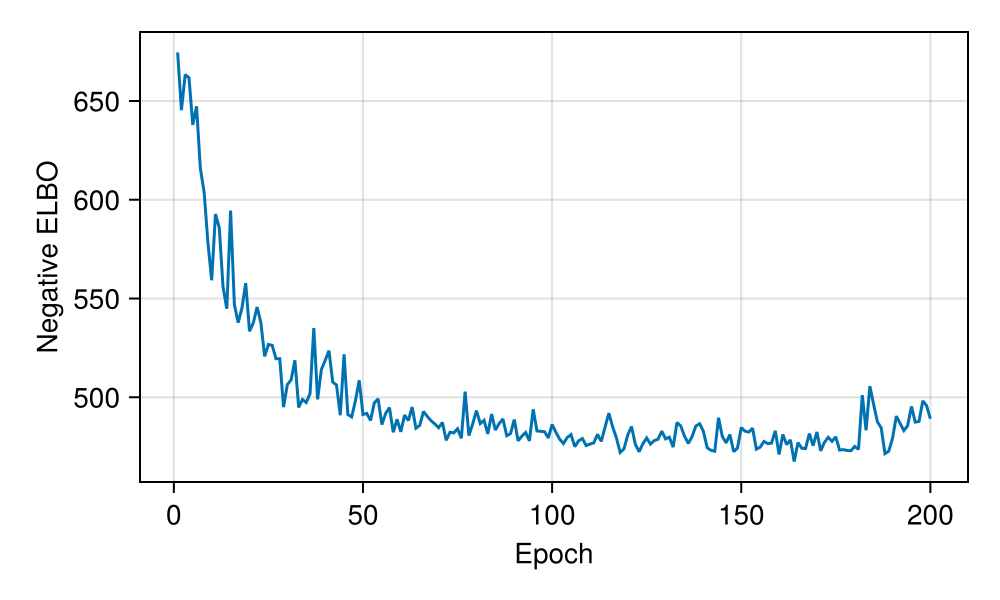

```julia
fig = Figure(size = (500, 300))
ax = Axis(fig[1, 1]; xlabel = "Epoch", ylabel = "Negative ELBO")
lines!(ax, losses)
fig
```

## Step 3: update Ω and the error model

The gradient steps above do not update `omega`, which is estimated in a separate *M-step*, as in classical EM algorithms for mixed-effects models: it is set to the second moment of the variational posteriors. `m_step` does this, and also re-estimates the residual error parameters.

```julia
ps_before = ps
ps = m_step(objective, rng, model, population, ps, st; epochs = 20, num_samples = 20, verbose = false)
(omega_before = [ps_before.omega[i, i] for i in 1:3], omega_after = [ps.omega[i, i] for i in 1:3])
```

```
(omega_before = Float32[0.1, 0.1, 0.1], omega_after = Float32[0.09895316, 0.059317965, 0.038245674])
```

Alternating gradient steps and M-steps a few times is the usual recipe. Here one round is enough for the demonstration.

## Predictions

By default `predict` uses each individual's own posterior (`individual = true`). With `individual = false` it uses the typical parameters `ζ(x)` only. The posterior is a distribution, so for a point prediction we set the noise to zero, which evaluates the posterior mean.

```julia
st_mean = deepcopy(st)
foreach(e -> e .= 0, st_mean.phi.epsilon)

ŷ_individual = predict(model, population, ps, st_mean)
ŷ_typical = predict(model, population, ps, st_mean; individual = false)

rmse(ŷ) = sqrt(mean(reduce(vcat, [(a .- b) .^ 2 for (a, b) in zip(ŷ, get_y(population))])))
(typical = rmse(ŷ_typical), individual = rmse(ŷ_individual))
```

```
(typical = 1.7578747f0, individual = 1.247446f0)
```

The individual predictions have a clearly lower error, as they should: they use information from the individual's own observations. Plotting a few subjects on a fine time grid needs the parameters of just that subject. `take_batch` slices `ps` and `st` for a set of individuals:

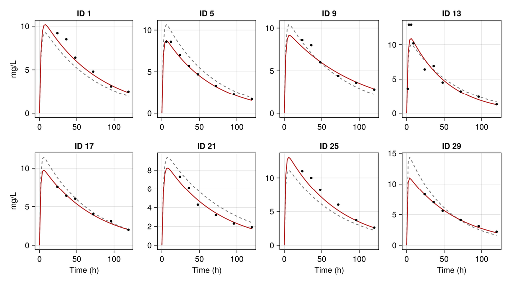

```julia
grid = Float32.(0:2:120)

function curves(i)
    ps_i, st_i = take_batch(ps, st_mean, [i])
    individual = predict(model, population[i:i], ps_i, st_i; saveat = grid)[1]
    typical = predict(model, population[i:i], ps_i, st_i; individual = false, saveat = grid)[1]
    return individual, typical
end

fig = Figure(size = (900, 500))
for (k, i) in enumerate([1, 5, 9, 13, 17, 21, 25, 29])
    local ax = Axis(fig[fld(k - 1, 4) + 1, mod1(k, 4)]; title = "ID $(population[i].id)",
              xlabel = k > 4 ? "Time (h)" : "", ylabel = mod1(k, 4) == 1 ? "mg/L" : "")
    individual, typical = curves(i)
    lines!(ax, grid, typical; color = :gray, linestyle = :dash)
    lines!(ax, grid, individual; color = :firebrick)
    scatter!(ax, get_t(population[i]), get_y(population[i]); color = :black, markersize = 6)
end
fig
```

The dashed gray line is the typical prediction for the covariates of that subject, the red line the individual prediction. The random effects themselves, one row per parameter, one column per individual, are available from `get_random_effects`:

```julia
η = get_random_effects(ps, st_mean)
(mean_η = vec(mean(η; dims = 2)), sd_η = vec(sqrt.(mean(abs2, η; dims = 2))))
```

```
(mean_η = Float32[-0.000686391, 0.03458405, -0.0042566145], sd_η = Float32[0.12538716, 0.22598119, 0.13444206])
```

Note

This is a short run to show the mechanics. In practice, train for more epochs with a decaying learning rate, check that the ELBO has flattened, and alternate gradient steps with `m_step` until `omega` stops moving.